# Visual attention to neutral vs competing vs reinforcing stimuli among children with ASD

**Author: Dominik Neumann**  
Michigan State University

# Setup

Please select “dat_visualattention.csv” for dat_attention data table and “dat_master.csv” for dat_master data table in order to run this script properly.  
Missing values were coded as -999. We coded “-“ values as -888, indicating participants looked at the center of the screen and thus at neither distracter nor target. We coded “.” values as -777, indicating participants looking outside of the screen.

# Data cleaning and transforming

## Missing values and underperforming trials

Our critical window is from 300 to 2000 ms after the onset of the target word. Trials on which children were not fixating either object for more than 50% of the critical window were excluded. These trials do not have adequate data and at the extreme could include instances where children looked at one object for a single frame at the start of the window and then looked away (and would therefore have 0 or 100% accuracy).

There were n = 397 trials with more than 50% missing values across variables assed, these were deleted, leading to 916 observed trials. **Table 1**

```
                    Process    n
1           Before cleaning 1313
2 Number of excluded trials  397
3            After cleaning  916
```

**Table 2**

```
          Process  N
1 Before cleaning 56
2  After cleaning 56
```

## Overview of missing data

**Table 4**

```
    item      group1 vars   n mean   sd median trimmed  mad min max range skew kurtosis   se
X11    1   competing    1 338  5.2 6.23      3    3.96 4.45   0  25    25 1.58     1.73 0.34
X12    2     neutral    1 352  5.2 6.51      3    3.84 4.45   0  25    25 1.60     1.57 0.35
X13    3 reinforcing    1 226  4.0 5.67      2    2.69 2.97   0  25    25 2.06     3.76 0.38
```

## Transformation to long data

In order to analyse data appropriately, data was transformed to a series of long datasets. First, a dataset for the analysis window only (frame 97 to frame 148) was created. Then, a dataset for all time points (frame 1 to frame 200) was created. Additionally, a dataset was generated that included the time before the analysis window as well as after the analysis window.

# Measuring Accuracy

“ACCURACY” is measured as ‘0’, ‘1’, or ‘NA’.  
1 = participant focuses on target at specific frame  
0 = participant focuses on the distracter at specific frame  
NA = participant focuses either on a point outside the screen (wall, machines, roof, etc.) or on the center of the screen (neither picture) at specific frame  
“MEAN ACCURACY” is measured as the mean of accuracy observations across individuals for each frame within a given conditions.

# Plotting Mean Accuracy by Condition

Figure 1 depicts development of mean accuracy. That is, the y-axis describes mean accuracy for all participants over all trials and the x-axis describes the time from beginning to end of the experiment. Mean accuracy measures are stratified by condition. We can see that children generally paid more attention to the correct stimulus in the “reinforcing condition”. Children further paid the least attention to the correct stimulus in the competing condition. However, an interesting orienting pattern emerged in the beginning, where participants focus on the correct picture first, then looked increasingly more at the wrong - more salient - stimulus, and then went back to the correct stimulus.

**Figure 1**

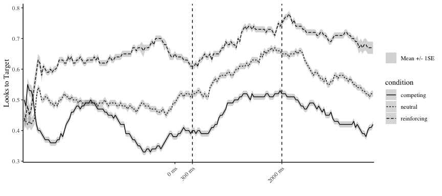

# Time series analysis

```
Linear mixed model fit by maximum likelihood . t-tests use Satterthwaite's method ['lmerModLmerTest']
Formula: mean_accuracy.c ~ Condition * frame.n + (1 | Child_ID) + (1 |      Tr_Num)
   Data: dat_attention_long

     AIC      BIC   logLik deviance df.resid
-38466.7 -38372.6  19242.4 -38484.7   255854

Scaled residuals:
    Min      1Q  Median      3Q     Max
-3.3596 -0.6344 -0.0227  0.6475  2.9453

Random effects:
 Groups   Name        Variance   Std.Dev.
 Child_ID (Intercept) 0.00368705 0.060721
 Tr_Num   (Intercept) 0.00003657 0.006048
 Residual             0.05029999 0.224277
Number of obs: 255863, groups:  Child_ID, 56; Tr_Num, 26

Fixed effects:
                               Estimate Std. Error         df t value Pr(>|t|)
(Intercept)                  -1.262e-01  8.346e-03  6.213e+01  -15.12   <2e-16 ***
Conditionneutral              5.390e-02  2.211e-03  2.670e+04   24.38   <2e-16 ***
Conditionreinforcing          1.878e-01  2.721e-03  4.873e+03   69.02   <2e-16 ***
frame.n                       2.737e-04  1.258e-05  2.558e+05   21.75   <2e-16 ***
Conditionneutral:frame.n      4.837e-04  1.774e-05  2.558e+05   27.27   <2e-16 ***
Conditionreinforcing:frame.n  4.377e-04  2.060e-05  2.558e+05   21.25   <2e-16 ***
---
Signif. codes:  0 ‘***’ 0.001 ‘**’ 0.01 ‘*’ 0.05 ‘.’ 0.1 ‘ ’ 1

Correlation of Fixed Effects:
            (Intr) Cndtnn Cndtnr fram.n Cndtnn:.
Conditnntrl -0.131
Cndtnrnfrcn -0.113  0.379
frame.n     -0.154  0.581  0.472
Cndtnntrl:.  0.109 -0.816 -0.335 -0.709
Cndtnrnfr:.  0.094 -0.355 -0.774 -0.611  0.433
```